# Simple Maize Model 🌽 📈

**Creating a model function, quantifying goodness-of-fit, and applying the model to Robeson County, NC**

### 1. Setup your workspace

This assignment requires functions from the following packages:

- `tidyverse`
- `lubridate`
- `janitor`

Load these packages to your workspace using the `library()` function. If you haven’t used these packages yet, you can install them using `install.packages()` (e.g., `install.packages("lubridate")`). Remember that you only have to install a package once, but you have to load the package to your workspace each time you’d like to work with it.

```r
library(tidyverse)
library(lubridate)
library(janitor)
```

### 2. Create a user-defined function: `maize_model()`

Create a function named `maize_model` that accepts the following arguments:

- The `weather` data frame, which includes columns named `day`, `Tmin`, `Tmax`, and `I`
- Parameters: `Tb`, `TTM`, `TTL`, `K`, `RUE`, `a`, `LAIm`
- Initial values for each of the state variables: `TT0`, `LAI0`, `B0`
- The first day of the simulation in Julian Days (e.g., if the simulation should start on February 1, the corresponding Julian Day would be 32): `start`
- The last day of the simulation in Julian Days: `end`
- Time step of the simulation: `step`

The model should **return** a data frame that includes the columns `day`, `B` (simulated biomass), `TT` (thermal time), and `LAI` (leaf area index).

To run the model, you should be able generate the maize model output using the following code:  
`maize_model(weather, Tb = 7, TTM = 1200, TTL = 700, K = 0.7, RUE = 1.85, a = 0.001,` `LAIm = 7, TT0 = 0, LAI0 = 0.1, B0 = 1, start = 1, end = 365, step = 1)`

To learn more about user-defined functions, refer to the Software Carpentry tutorial on [“Creating Functions”](https://swcarpentry.github.io/r-novice-inflammation/02-func-R/).

```r
# Run model
weather <- read_csv("data/weather_observations.csv")
function_outputs <-
  maize_model(weather,
              Tb = 7, TTM = 1200, TTL = 700,
              K = 0.7, RUE = 1.85, a = 0.001, LAIm = 7,
              TT0 = 0, LAI0 = 0.1, B0 = 1,
              start = 1, end = 365, step = 1)
```

```r
# Inspect new output
head(function_outputs)
```

```
##   day TT LAI        B
## 1   1  0 0.1 1.000000
## 2   2  0 0.1 1.187607
## 3   3  0 0.1 1.337693
## 4   4  0 0.1 1.625357
## 5   5  0 0.1 1.812964
## 6   6  0 0.1 1.963050
```

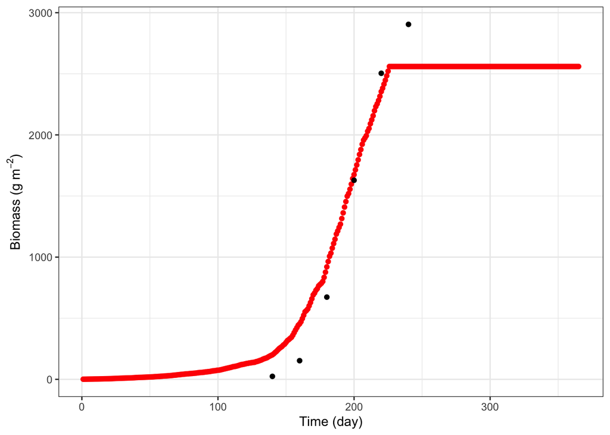

```r
observations <- read_csv("data/state_variable_observations.csv")

ggplot() +
  geom_point(data = function_outputs,
             aes(x = day, y = B),
             color = "red") +
  geom_point(data = observations,
             aes(x = day, y = Bobs)) +
  theme_bw() +
  labs(x = "Time (day)",
       y = expression("Biomass (g "*m^{-2}*")"))
```

### 3. Evaluate goodness-of-fit

From the `function_outputs`, calculate the model’s goodness-of-fit using observations in `data/state_variable_observations.csv`. As a first step, I recommend creating a new dataframe in which you combine the observational data with `function_outputs` using `left_join()`, e.g.: `left_join(observations, function_outputs)`.

Specifically, evaluate the goodness-of-fit of the maize model with the following:

- **Graphical representation**: Create a 1-to-1 plot with your simulated and observed maize biomass data, including a 45 degree line (use `geom_abline()`). To include superscripts in the axis labels, the `expression` function can be used, e.g.: `y = expression("Observed biomass (g "*m^{-2}*")")`

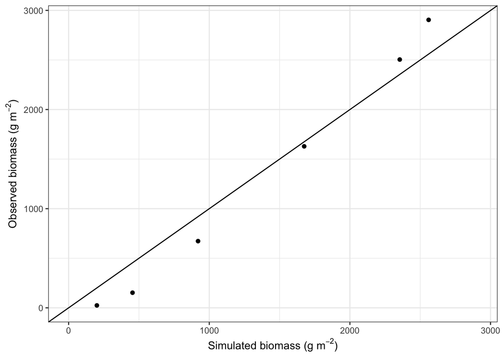

- **Quantify performance metrics**: root mean square error, efficiency, correlation coefficient, and bias
  - RMSE = $\sqrt{\frac{1}{n}\sum_{i = 1}^{n}(y_{i}-\hat{y}_{i})^2}$ = 233.38 g/m<sup>2</sup>
  - EF = $1-\frac{\sum_{i = 1}^{n}(y_{i}-\hat{y}_{i})^2}{\sum_{i = 1}^{n} (y_{i}-\overline{y}_{i})^2}$ = 0.96
  - r = `cor()` (Pearson is the default method) = 1
  - bias = $\frac{1}{n}\sum_{i = 1}^{n} (y_{i}-\hat{y}_{i})$ = -46.18 g/m<sup>2</sup>

**Pause, think, discuss**. Based on your 1-to-1 plot, were these the values you expected or did they surprise you? Based on the plot that shows all simulated values (the plot with the red line), do you feel these metrics are reflective of model performance? Explain in at least 3 sentences in your script or markdown file.

### 4. Apply the maize model to estimate average county-scale corn yields in Robeson County, NC

In this last step of the exercise, you will apply the maize model to estimate average corn yields in Robeson County, NC. The Robeson County maize model will be run using weather data collected in the city of Lumberton, and validated using annual data captured by the USDA National Agricultural Statistics Survey. To run the model, you have to ensure your inputs (i.e. weather data) and observational data are formatted correctly so that the model can run. In particular, based on the way the model is coded, the weather dataframe must have a row for each Julian Day in a year.

**Data**

The data are in two files located in the `data` folder:

- Daily weather data from Lumberton, 2016 - 2018: `weather_lumberton_2016_2018.csv`
- Corn yields from Robeson County, NC, 2014 - 2018: `usda_nass_corn_yields.csv`

**Tidy the yield data (`observations`)**

This file is pretty messy, but we’re ultimately only interested in having three values: observed corn yields in Robeson County in the years 2016, 2017, and 2018. To clean the data, complete the following steps:

- **Change the column names using `clean_names()`.** The `clean_names()` function is in the `janitor` package, and it converts all of your column names to “snake case”.
- **Filter the data to only include the columns and rows of interest**. This can be done with `filter()` and `dplyr::select()`. We only want to keep rows that correspond to: (1) Robeson County, (2) `data_item` == “CORN, GRAIN - YIELD, MEASURED IN BU / ACRE”, and (3) year > 2015. The only columns that need to be kept are `year`, `county`, `data_item`, and `value`.
- **Convert `value` to numeric**.

Once you’ve completed these steps, you should have the following as your output when you run `head(data)`:

```
## # A tibble: 3 × 4
##    year county  data_item                                  value
##   <dbl> <chr>   <chr>                                      <dbl>
## 1  2018 ROBESON CORN, GRAIN - YIELD, MEASURED IN BU / ACRE  112.
## 2  2017 ROBESON CORN, GRAIN - YIELD, MEASURED IN BU / ACRE  132.
## 3  2016 ROBESON CORN, GRAIN - YIELD, MEASURED IN BU / ACRE  130.
```

**Tidy the `weather` data**

The data need to be cleaned prior to running the model. Be sure to complete the following steps to tidy the data:

- **Rename the columns**. Change the column names so they are compatible with the names you use in the `maize_model` function (i.e. `Tmin`, `Tmax`, `I`, `day`). You should use `day` as the name for the datetime column.
- **Change the data types**. Convert character columns to numeric using `as.numeric()`. Convert the date column using the `lubridate` function, `mdy()`.
- **Add a `year` column**. Use `mutate(year = year(day))`.
- **Convert the units**. `Tmin` and `Tmax` are currently in deg F and `I` is a daily average in W/m<sup>2</sup>. The model requires the data to be in deg C and MJ m<sup>-2</sup> day<sup>-1</sup>. To convert from deg F to deg C, use the formula $(T - 32) * 5/9$. To convert from W to MJ/day, use the formula $(I * 0.0036) * 24$.
- **Replace NAs**. There are a few missing values in the weather data, which will result in the model not being able to run properly. To remedy this issue, fill the NA values with the observations from the prior time step. This can be done quickly using `weather %>% fill(Tmin, Tmax, I, .direction = "down") -> weather`. Confirm that the missing values have been filled (hint: you can use `which(is.na(weather))` to identify which rows have NA values).

Once you’ve completed these steps, you should have the following as your output when you run `head(weather)`:

```
## # A tibble: 6 × 5
##   day         Tmax   Tmin     I  year
##   <date>     <dbl>  <dbl> <dbl> <dbl>
## 1 2016-01-01 15     9.39   4.18  2016
## 2 2016-01-02 12.2   3.89   9.36  2016
## 3 2016-01-03 10     0.611  6.16  2016
## 4 2016-01-04  7.78  1.11  11.6   2016
## 5 2016-01-05  3.89 -2.78  13.1   2016
## 6 2016-01-06  8.28 -3.28   9.36  2016
```

**Run the model for 2016, 2017, and 2018**

Using the cleaned data and `maize_model` function, run the maize model for Robeson County and compare your simulated corn yields to the observed. You will run the model separately for 2016, 2017, and 2018. Your simulation period should correspond to the growing season, which we will estimate as starting on May 5th (Julian Day == 125) and ending on September 15th (Julian Day == 258). The **final simulated yield** (i.e., yield on Julian Day == 258) is what we will compare to the observational data.

I recommend creating separate weather data frames for each of the three years, e.g. `weather2016 <- filter(weather, year == 2016)`. These dataframes can then be used when you run `maize_model` for each of the three years.

Use the following parameter and initial values when running the model:

```r
Tb    <- 12.8
TTM   <- 1400
TTL   <- 700
K     <- 1
RUE   <- 1.5
a     <- 0.001
LAIm  <- 7
TT0   <- 0
LAI0  <- 0.1
B0    <- 0.1
start <- 125
end   <- 258
step  <- 1
```

For each model run, you should save the simulated corn yield for September 15th in a data frame. Initialize this data frame such that you can populate it as you run the model for each year.

```r
outputs_robeson <- data.frame(year = c(2016, 2017, 2018),
                              simulated = rep(NA, 3),
                              observed = observations$value[3:1])
outputs_robeson
```

```
##   year simulated observed
## 1 2016        NA    130.5
## 2 2017        NA    132.4
## 3 2018        NA    111.9
```

After running the model for 2016, 2017, and 2018, your outputs should include:

```
##   year simulated observed
## 1 2016  731.2422    130.5
## 2 2017 1069.3121    132.4
## 3 2018  794.7068    111.9
```

Note that the observed yields are in bushels per acre, but the simulated yields are in g per m<sup>2</sup>. To convert the simulated yields from g/m<sup>2</sup> to bushels/acre, use the formula: $yield * 10^{-6} * 39.37 * 4046.86$.

```
##   year simulated observed
## 1 2016  116.5051    130.5
## 2 2017  170.3680    132.4
## 3 2018  126.6166    111.9
```

**Pause, think, discuss**. Based on the information you have, do you think the model performed well? Why or why not? Explain in at least 3 sentences in your script or markdown file.

**Once you’re done, submit your script or markdown file via GitHub; you can submit multiple files if you wish. The file(s) should include code (maize model, user-defined function, goodness-of-fit, Robeson County application), as well as responses to the two “pause, think, discuss” prompts.**